# W5&6_post_studio_notebook_solutions

## W5&W6 post studio exercises (time series, imputation)

Enter your solution in the cell(s) below each exercise. Add couple of inline comments explaining your code. Don't forget to add comments in markdown cell after each exercise. Missing comments (in markdown cells and/or inline) and late submissions will incur penalties.

Once done, drag&drop your python file to your ADS1002-name github account.

Copy url of this file on github to appropriate folder on Moodle by 09.30am prior your next studio.

Solutions will be released later in the semester.

Max 10 marks - 2.5 marks per each exercise.

Required files (download these from the Gitlab site into the same directory as the notebook on your computer):

- traffic-data.csv
- abalone.csv

Once downloaded, run the following cells and use these dataframes in the exercises.

```python
import numpy as np
from matplotlib import pyplot as plt
import seaborn as sns
```

```python
import pandas as pd
# traffic data -Q1, Q2, Q5, Q6
raw_traffic_data = pd.read_csv("traffic-data.csv")

# Create a new index from the timestamp column, with the proper type.
traffic_data = raw_traffic_data.set_index(pd.to_datetime(raw_traffic_data["Timestamp"]))

# Delete the column with our old string representation of times.
traffic_data = traffic_data.drop(columns=["Timestamp"])

traffic_data = traffic_data.assign(
    Date=lambda df: df.index.floor("D"),
    TimeOfDay=lambda df: df.index - df.Date,
    DayOfWeek=lambda df: df.index.day_name().astype("category"),
)
```

Abalone dataset - This consists of physical measurements of abalones from the Tasmanian coast in the 1990s, in an effort to determine their age. Previously the age would need to be determined in the laboratory by counting the number of rings in the shell. Relationship used to determine age is: *Age* = *# of rings + 1.5*.

This is a complete dataset, however we will randomly remove entries in two columns to perform imputation.

First we load the dataset.

```python
abalone = pd.read_csv("abalone.csv")
abalone.head()
```

|  | Sex | Length | Diameter | Height | Whole weight | Shucked weight | Viscera weight | Shell weight | Rings |
| --- | --- | --- | --- | --- | --- | --- | --- | --- | --- |
| 0 | M | 0.455 | 0.365 | 0.095 | 0.5140 | 0.2245 | 0.1010 | 0.150 | 15 |
| 1 | M | 0.350 | 0.265 | 0.090 | 0.2255 | 0.0995 | 0.0485 | 0.070 | 7 |
| 2 | F | 0.530 | 0.420 | 0.135 | 0.6770 | 0.2565 | 0.1415 | 0.210 | 9 |
| 3 | M | 0.440 | 0.365 | 0.125 | 0.5160 | 0.2155 | 0.1140 | 0.155 | 10 |
| 4 | I | 0.330 | 0.255 | 0.080 | 0.2050 | 0.0895 | 0.0395 | 0.055 | 7 |

The Sex field has three categorical entries: Male (M), Female (F) and Infant (I). Se we need to **one-hot encode** these fields to create three binary columns (encode categorical features to equivalent numerical information).

```python
dummy = pd.get_dummies(abalone['Sex'])
abalone = pd.concat([abalone, dummy], axis=1)
abalone.drop(columns=['Sex'], inplace=True)
abalone.head()
```

|  | Length | Diameter | Height | Whole weight | Shucked weight | Viscera weight | Shell weight | Rings | F | I | M |
| --- | --- | --- | --- | --- | --- | --- | --- | --- | --- | --- | --- |
| 0 | 0.455 | 0.365 | 0.095 | 0.5140 | 0.2245 | 0.1010 | 0.150 | 15 | 0 | 0 | 1 |
| 1 | 0.350 | 0.265 | 0.090 | 0.2255 | 0.0995 | 0.0485 | 0.070 | 7 | 0 | 0 | 1 |
| 2 | 0.530 | 0.420 | 0.135 | 0.6770 | 0.2565 | 0.1415 | 0.210 | 9 | 1 | 0 | 0 |
| 3 | 0.440 | 0.365 | 0.125 | 0.5160 | 0.2155 | 0.1140 | 0.155 | 10 | 0 | 0 | 1 |
| 4 | 0.330 | 0.255 | 0.080 | 0.2050 | 0.0895 | 0.0395 | 0.055 | 7 | 0 | 1 | 0 |

Lastly we create a features array (X_full) and a target array (Y), the target being Rings. Then we randomly remove 33% of the Height samples and 25% of the Shell weight samples from the features array to get X_rm.

```python
X_full = abalone.drop(columns=['Rings'])
Y = abalone[['Rings']]

X_rm = X_full.copy()
X_rm['Height'] = X_rm['Height'].sample(frac=0.67, random_state = 42)
X_rm['Shell weight'] = X_rm['Shell weight'].sample(frac=0.75, random_state = 64)

#X_rm.describe()
```

### Exercise 1 (Filtering - traffic_data)

Plot only the data (from the full day) for 18th January 2021 for Site 107 as a line plot. What is the busiest period of the day? Are there any issues with this data? Show data between 1pm and 3pm and comment on the values.

#### Ex 1 solution

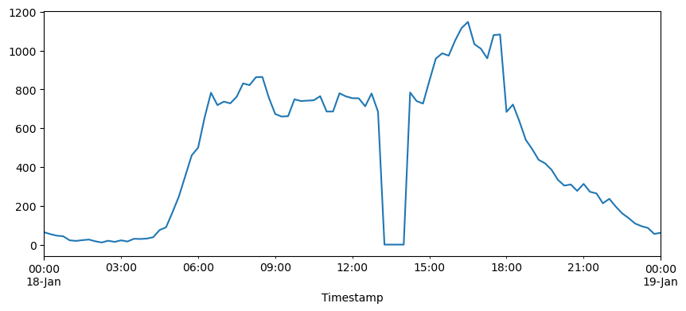

```python
# Define the desired timestamps

start = pd.Timestamp('2021-01-18 00:00:00')
end = start + pd.Timedelta(days = 1)

ex1_data = traffic_data.loc[start:end,'Site 107']

ex1_data.plot(figsize = (10, 4));
```

The busiest period of the day seems to be around 5pm-6pm. Probably due to peak hour!

There seems to be an issue with the data around 1:30pm. We can examine this further.

```python
ex1_data[pd.Timestamp('2021-01-18 13:00:00'):pd.Timestamp('2021-01-18 15:00:00')]
```

```
Timestamp
2021-01-18 13:00:00    685.0
2021-01-18 13:15:00      0.0
2021-01-18 13:30:00      0.0
2021-01-18 13:45:00      0.0
2021-01-18 14:00:00      0.0
2021-01-18 14:15:00    784.0
2021-01-18 14:30:00    740.0
2021-01-18 14:45:00    727.0
2021-01-18 15:00:00    845.0
Name: Site 107, dtype: float64
```

As we can see, there seems to be some 0s from 1:15pm - 2:00pm. This is most definitely not accurate, rather this is an indicator of missing values.

Extra (students not required to provide code and discussion below):

We can use a more quantitative approach to check if there are any other 0s in this column.

```python
(ex1_data == 0).sum()
```

```
4
```

So it's just these values around 1:30pm. We can impute these values... If you want to check this out now, a good place to start is to study the .replace() and .fillna() methods from pandas.

### Exercise 2 (Resampling - traffic_data)

Calculate and plot the number of cars seen in the busiest 15 minute period each day for Site 103 (i.e. the maximum of all 15 minute periods across each day). What do you observe?

#### Exercise 2 Solution

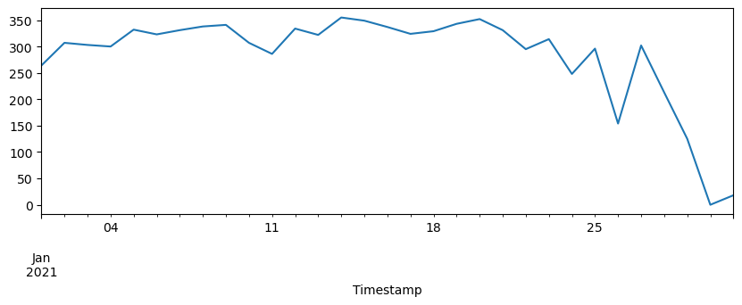

```python
ex2_data = traffic_data['Site 103']

dailymax_ex2_data = ex2_data.resample('D').max()

dailymax_ex2_data.plot(figsize = (10, 3));
```

It seems like near the end January there was a substantial decrease in the amount of traffic at Site 103. Perhaps there were some sort of roadworks or road closures around these days.

### Exercise 3 (Imputing with mean or median - using X_rm based on abalone)

Consider the dataframe X_simple_imputer below.

For this dataframe:

- Show counts of missing data for all columns.
- Impute the missing values in the Height column with its mean.
- Impute the missing values in the Shell weight column with its median.
- Show first 10 rows after imputation.
- Show counts of missing data after imputation.

```python
X_simple_imputer = X_rm.copy()

# You may use pandas fill.na() method or SciKit-Learn's simple imputer.
```

#### Exercise 3 Solution

It's always a good idea to run the following command to determine which columns have missing values.

```python
X_simple_imputer.isna().sum()
```

```
Length               0
Diameter             0
Height            1378
Whole weight         0
Shucked weight       0
Viscera weight       0
Shell weight      1044
F                    0
I                    0
M                    0
dtype: int64
```

The Height and Shell weight columns have missing values (clearly...as we artificially removed them in the first place!). So we impute them with the mean and median of those columns respectively.

```python
X_simple_imputer['Height'] = X_simple_imputer['Height'].fillna(X_simple_imputer['Height'].mean())
X_simple_imputer['Shell weight'] = X_simple_imputer['Shell weight'].fillna(X_simple_imputer['Shell weight'].median())
X_simple_imputer.head(10)
```

|  | Length | Diameter | Height | Whole weight | Shucked weight | Viscera weight | Shell weight | F | I | M |
| --- | --- | --- | --- | --- | --- | --- | --- | --- | --- | --- |
| 0 | 0.455 | 0.365 | 0.095000 | 0.5140 | 0.2245 | 0.1010 | 0.150 | 0 | 0 | 1 |
| 1 | 0.350 | 0.265 | 0.139176 | 0.2255 | 0.0995 | 0.0485 | 0.070 | 0 | 0 | 1 |
| 2 | 0.530 | 0.420 | 0.135000 | 0.6770 | 0.2565 | 0.1415 | 0.210 | 1 | 0 | 0 |
| 3 | 0.440 | 0.365 | 0.139176 | 0.5160 | 0.2155 | 0.1140 | 0.155 | 0 | 0 | 1 |
| 4 | 0.330 | 0.255 | 0.139176 | 0.2050 | 0.0895 | 0.0395 | 0.055 | 0 | 1 | 0 |
| 5 | 0.425 | 0.300 | 0.139176 | 0.3515 | 0.1410 | 0.0775 | 0.235 | 0 | 1 | 0 |
| 6 | 0.530 | 0.415 | 0.150000 | 0.7775 | 0.2370 | 0.1415 | 0.235 | 1 | 0 | 0 |
| 7 | 0.545 | 0.425 | 0.125000 | 0.7680 | 0.2940 | 0.1495 | 0.260 | 1 | 0 | 0 |
| 8 | 0.475 | 0.370 | 0.125000 | 0.5095 | 0.2165 | 0.1125 | 0.235 | 0 | 0 | 1 |
| 9 | 0.550 | 0.440 | 0.139176 | 0.8945 | 0.3145 | 0.1510 | 0.320 | 1 | 0 | 0 |

As you can see, there are now no more missing values in the X_simple_imputer dataframe.

```python
X_simple_imputer.isna().sum()
```

```
Length            0
Diameter          0
Height            0
Whole weight      0
Shucked weight    0
Viscera weight    0
Shell weight      0
F                 0
I                 0
M                 0
dtype: int64
```

```python
# using SimpleImputer
from sklearn.impute import SimpleImputer

X_simple_imputer = X_rm.copy()

tmp1 = SimpleImputer(strategy = 'mean').fit_transform(pd.DataFrame(X_simple_imputer['Height']))
X_simple_imputer['Height'] = tmp1

tmp2 = SimpleImputer(strategy = 'median').fit_transform(pd.DataFrame(X_simple_imputer['Shell weight']))
X_simple_imputer['Shell weight'] = tmp2
X_simple_imputer.head(10)
```

|  | Length | Diameter | Height | Whole weight | Shucked weight | Viscera weight | Shell weight | F | I | M |
| --- | --- | --- | --- | --- | --- | --- | --- | --- | --- | --- |
| 0 | 0.455 | 0.365 | 0.095000 | 0.5140 | 0.2245 | 0.1010 | 0.150 | 0 | 0 | 1 |
| 1 | 0.350 | 0.265 | 0.139176 | 0.2255 | 0.0995 | 0.0485 | 0.070 | 0 | 0 | 1 |
| 2 | 0.530 | 0.420 | 0.135000 | 0.6770 | 0.2565 | 0.1415 | 0.210 | 1 | 0 | 0 |
| 3 | 0.440 | 0.365 | 0.139176 | 0.5160 | 0.2155 | 0.1140 | 0.155 | 0 | 0 | 1 |
| 4 | 0.330 | 0.255 | 0.139176 | 0.2050 | 0.0895 | 0.0395 | 0.055 | 0 | 1 | 0 |
| 5 | 0.425 | 0.300 | 0.139176 | 0.3515 | 0.1410 | 0.0775 | 0.235 | 0 | 1 | 0 |
| 6 | 0.530 | 0.415 | 0.150000 | 0.7775 | 0.2370 | 0.1415 | 0.235 | 1 | 0 | 0 |
| 7 | 0.545 | 0.425 | 0.125000 | 0.7680 | 0.2940 | 0.1495 | 0.260 | 1 | 0 | 0 |
| 8 | 0.475 | 0.370 | 0.125000 | 0.5095 | 0.2165 | 0.1125 | 0.235 | 0 | 0 | 1 |
| 9 | 0.550 | 0.440 | 0.139176 | 0.8945 | 0.3145 | 0.1510 | 0.320 | 1 | 0 | 0 |

### Exercise 4 (kNN imputer - X_rm dataframe based on abalone)

Consider the dataframe X_kNN_imputer below. Utilise the kNN imputer with n_neighbors = 5 in order to fill in the missing values of X_kNN_imputer. As we have one hot encoded our data, we will use the MinMaxScaler from SciKit-Learn to normalise our data. After you have done your kNN imputation, please unnormalise your data afterwards!

```python
from sklearn.impute import KNNImputer
from sklearn.preprocessing import MinMaxScaler

X_kNN_imputer = X_rm.copy()
Y_kNN_imputer = Y.copy()

# Instantiate the MinMaxScaler
scaler = MinMaxScaler()

# Keep track of the columns
X_columns = X_kNN_imputer.columns

# Now we normalise the data using the MinMaxScaler. The method used is fit_transform
X_kNN_imputer = pd.DataFrame(scaler.fit_transform(X_kNN_imputer), columns = X_columns)
X_kNN_imputer.head(10)

# X_kNN_imputer has now been normalised. Please do your kNN imputation on this normalised dataframe, and
# then unnormalise your data afterwards using the inverse_transform method of the MinMaxScaler
```

|  | Length | Diameter | Height | Whole weight | Shucked weight | Viscera weight | Shell weight | F | I | M |
| --- | --- | --- | --- | --- | --- | --- | --- | --- | --- | --- |
| 0 | 0.513514 | 0.521008 | 0.075893 | 0.181335 | 0.150303 | 0.132324 | 0.147982 | 0.0 | 0.0 | 1.0 |
| 1 | 0.371622 | 0.352941 | NaN | 0.079157 | 0.066241 | 0.063199 | 0.068261 | 0.0 | 0.0 | 1.0 |
| 2 | 0.614865 | 0.613445 | 0.111607 | 0.239065 | 0.171822 | 0.185648 | 0.207773 | 1.0 | 0.0 | 0.0 |
| 3 | 0.493243 | 0.521008 | NaN | 0.182044 | 0.144250 | 0.149440 | 0.152965 | 0.0 | 0.0 | 1.0 |
| 4 | 0.344595 | 0.336134 | NaN | 0.071897 | 0.059516 | 0.051350 | 0.053313 | 0.0 | 1.0 | 0.0 |
| 5 | 0.472973 | 0.411765 | NaN | 0.123783 | 0.094149 | 0.101382 | NaN | 0.0 | 1.0 | 0.0 |
| 6 | 0.614865 | 0.605042 | 0.125000 | 0.274659 | 0.158709 | 0.185648 | NaN | 1.0 | 0.0 | 0.0 |
| 7 | 0.635135 | 0.621849 | 0.102679 | 0.271294 | 0.197041 | 0.196182 | 0.257598 | 1.0 | 0.0 | 0.0 |
| 8 | 0.540541 | 0.529412 | 0.102679 | 0.179741 | 0.144923 | 0.147465 | NaN | 0.0 | 0.0 | 1.0 |
| 9 | 0.641892 | 0.647059 | NaN | 0.316097 | 0.210827 | 0.198157 | 0.317389 | 1.0 | 0.0 | 0.0 |

#### Exercise 4 Solution

```python
from sklearn.impute import KNNImputer

X_kNN_imputer = KNNImputer(n_neighbors=5).fit_transform(X_kNN_imputer)

X_kNN_imputer = pd.DataFrame(scaler.inverse_transform(X_kNN_imputer), columns = X_columns)
X_kNN_imputer.head(10)
```

|  | Length | Diameter | Height | Whole weight | Shucked weight | Viscera weight | Shell weight | F | I | M |
| --- | --- | --- | --- | --- | --- | --- | --- | --- | --- | --- |
| 0 | 0.455 | 0.365 | 0.095 | 0.5140 | 0.2245 | 0.1010 | 0.1500 | 0.0 | 0.0 | 1.0 |
| 1 | 0.350 | 0.265 | 0.094 | 0.2255 | 0.0995 | 0.0485 | 0.0700 | 0.0 | 0.0 | 1.0 |
| 2 | 0.530 | 0.420 | 0.135 | 0.6770 | 0.2565 | 0.1415 | 0.2100 | 1.0 | 0.0 | 0.0 |
| 3 | 0.440 | 0.365 | 0.118 | 0.5160 | 0.2155 | 0.1140 | 0.1550 | 0.0 | 0.0 | 1.0 |
| 4 | 0.330 | 0.255 | 0.085 | 0.2050 | 0.0895 | 0.0395 | 0.0550 | 0.0 | 1.0 | 0.0 |
| 5 | 0.425 | 0.300 | 0.107 | 0.3515 | 0.1410 | 0.0775 | 0.0929 | 0.0 | 1.0 | 0.0 |
| 6 | 0.530 | 0.415 | 0.150 | 0.7775 | 0.2370 | 0.1415 | 0.2503 | 1.0 | 0.0 | 0.0 |
| 7 | 0.545 | 0.425 | 0.125 | 0.7680 | 0.2940 | 0.1495 | 0.2600 | 1.0 | 0.0 | 0.0 |
| 8 | 0.475 | 0.370 | 0.125 | 0.5095 | 0.2165 | 0.1125 | 0.1583 | 0.0 | 0.0 | 1.0 |
| 9 | 0.550 | 0.440 | 0.145 | 0.8945 | 0.3145 | 0.1510 | 0.3200 | 1.0 | 0.0 | 0.0 |

## Extra exercises

The following exercises with (*) will not be assessed. Use these to check your understanding of topics covered in the past 2 weeks.

### Exercise 5* (Rolling - traffic_data)

Plot the 2-hourly rolling mean, over the first week of January for Site 109. What is the busiest day in this period?

#### Exercise 5 Solution

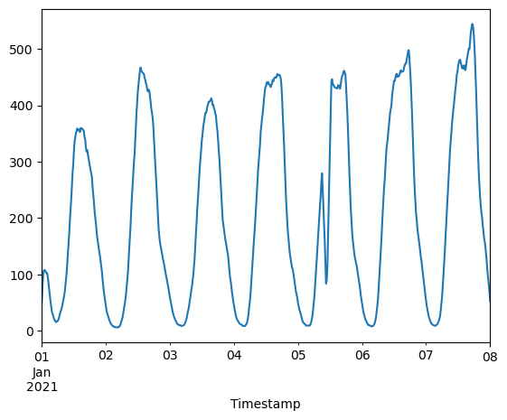

```python
# Define the desired timestamps
start = pd.Timestamp('2021-01-01 00:00:00')
end = start + pd.Timedelta(weeks = 1)

ex3_data = traffic_data.loc[start:end, 'Site 109']

rolling_ex3_data = ex3_data.rolling('2H').mean()
rolling_ex3_data.plot();
```

Before studying which day is busiest day here, we should first determine what day Jan 01 2021 is.

```python
pd.Timestamp('2021-01-01').day_name()
```

```
'Friday'
```

Knowing this, it looks like Thursday Jan 07 2021 is the busiest day during this week. This may be due to people returning to work after the New Year Holiday break.

### Exercise 6* (Pivot/aggregate - traffic_data)

Plot the maximum traffic seen in each 15 minute window of the day on any Monday in the dataset for any two sites. What is the busiest time of day on a Monday at the sites you have chosen?

#### Exercise 6 Solution

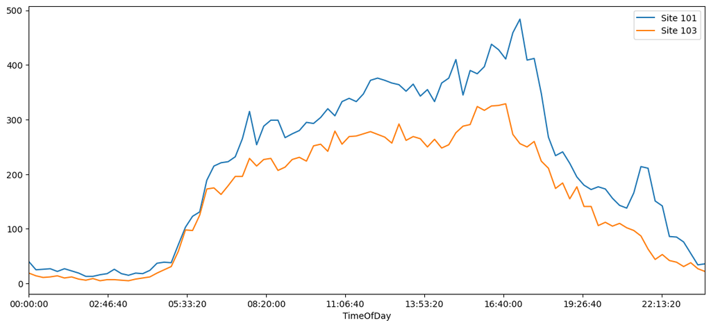

```python
# Hint: this dataframe already contains TimeOfDay and DayOfWeek which you can use for
# group and pivot operations.

ex4_data = traffic_data.query('DayOfWeek == "Monday"')
monday_two_sites = ex4_data[['Site 101', 'Site 103', 'TimeOfDay']]
monday_two_sites.groupby('TimeOfDay').max().plot(figsize = (14, 6));
```

From the plot, it seems like the busiest periods of times on Mondays for these sites are both around 5pm.

### Exercise 7* (Distributions for different imouters - abalone)

Plot histograms of:

The distribution of the Height feature in the X_simple_imputer dataframe. The distribution of the Shell weight feature in the X_simple_imputer dataframe. The distribution of the Height feature in the X_kNN_imputer dataframe. The distribution of the Shell weight feature in the X_kNN_imputer dataframe.

```python
# Use the following command to set up a figure with 4 subplots.

# fig, axes = plt.subplots(2, 2, figsize=(10, 10));
```

#### Exercise 7 Solution

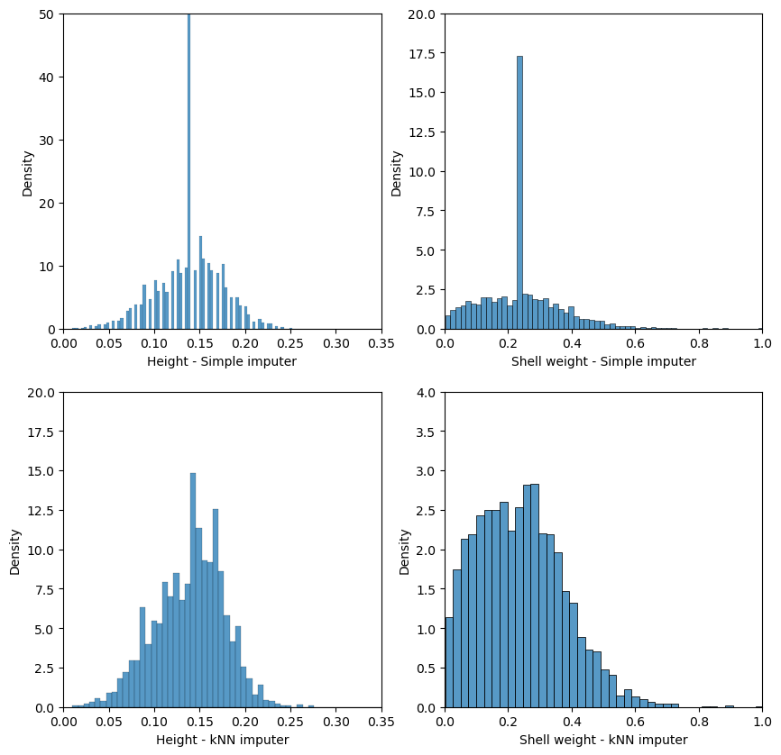

```python
fig, axes = plt.subplots(2, 2, figsize=(10, 10))

sns.histplot(X_simple_imputer, x="Height", stat="density", ax = axes[0, 0])
sns.histplot(X_kNN_imputer, x="Height", stat="density", ax = axes[1, 0])
sns.histplot(X_simple_imputer, x="Shell weight", stat="density", ax = axes[0, 1])
sns.histplot(X_kNN_imputer, x="Shell weight", stat="density", ax = axes[1, 1])

axes[0, 0].set_xlim(0, 0.35);
axes[0, 0].set_ylim(0, 50);
axes[0, 0].set_xlabel('Height - Simple imputer')

axes[1, 0].set_xlim(0, 0.35);
axes[1, 0].set_ylim(0, 20);
axes[1, 0].set_xlabel('Height - kNN imputer')

axes[0, 1].set_xlim(0, 1);
axes[0, 1].set_ylim(0, 20);
axes[0, 1].set_xlabel('Shell weight - Simple imputer')

axes[1, 1].set_xlim(0, 1);
axes[1, 1].set_ylim(0, 4);
axes[1, 1].set_xlabel('Shell weight - kNN imputer');
```

### Exercise 8* (kNN imputer for regression model - abalone)

Below I have created a k-Nearest Neighbours Regression (not Classification!) model for the full dataset X_full and determined the R2 score of the model. Here I have chosen n_neighbours = 5 and I have used a 80:20 split for training and testing.

You have two tasks. In both tasks you should use n_neighbors = 5 and an 80:20 split for training and testing.

Create a k-Nearest Neighbours model for the X_simple_imputer dataset and determine the R2 score of this model. Create a k-Nearest Neighbours model for the X_kNN_imputer dataset and determine the R2 score of this model. Are the R2 scores as you expected?

N.B. Remember that the kNN algorithm utilises Euclidean distance in order to calculate distances between features, and therefore requires the feature set to be normalised. This normalisation is done in the code for you.

```python
X_ex4 = X_full.copy()
Y_ex4 = Y.copy()
X_columns = X_ex4.columns
```

```python
# Fit the kNN model with the X_full dataframe. This is done for you as an example.

from sklearn.neighbors import KNeighborsRegressor
from sklearn.model_selection import train_test_split
from sklearn.metrics import r2_score

# Normalise the data for the kNN algorithm
X_ex4 = pd.DataFrame(scaler.fit_transform(X_ex4), columns = X_columns)

X_train, X_test, Y_train, Y_test = train_test_split(X_ex4, Y_ex4, test_size=0.2, random_state = 0)
kNN = KNeighborsRegressor(n_neighbors = 5)
kNN.fit(X_train, Y_train) # fit the data to the model
Y_pred = kNN.predict(X_test) # Predict the target values from the test feature data
acc = r2_score(Y_test,Y_pred)

print(f'R2 score is {acc:.3f}')
```

```
R2 score is 0.507
```

```python
# Task 1: Fit a kNN model with the X_simple_imputer dataframe and compute the r2 score.

# Normalise data for kNN algorithm
X_simple_imputer = pd.DataFrame(scaler.fit_transform(X_simple_imputer), columns = X_columns)

X_simple_imputer
```

|  | Length | Diameter | Height | Whole weight | Shucked weight | Viscera weight | Shell weight | F | I | M |
| --- | --- | --- | --- | --- | --- | --- | --- | --- | --- | --- |
| 0 | 0.513514 | 0.521008 | 0.075893 | 0.181335 | 0.150303 | 0.132324 | 0.147982 | 0.0 | 0.0 | 1.0 |
| 1 | 0.371622 | 0.352941 | 0.115336 | 0.079157 | 0.066241 | 0.063199 | 0.068261 | 0.0 | 0.0 | 1.0 |
| 2 | 0.614865 | 0.613445 | 0.111607 | 0.239065 | 0.171822 | 0.185648 | 0.207773 | 1.0 | 0.0 | 0.0 |
| 3 | 0.493243 | 0.521008 | 0.115336 | 0.182044 | 0.144250 | 0.149440 | 0.152965 | 0.0 | 0.0 | 1.0 |
| 4 | 0.344595 | 0.336134 | 0.115336 | 0.071897 | 0.059516 | 0.051350 | 0.053313 | 0.0 | 1.0 | 0.0 |
| ... | ... | ... | ... | ... | ... | ... | ... | ... | ... | ... |
| 4172 | 0.662162 | 0.663866 | 0.115336 | 0.313441 | 0.248151 | 0.314022 | 0.232686 | 1.0 | 0.0 | 0.0 |
| 4173 | 0.695946 | 0.647059 | 0.111607 | 0.341420 | 0.294553 | 0.281764 | 0.232686 | 0.0 | 0.0 | 1.0 |
| 4174 | 0.709459 | 0.705882 | 0.174107 | 0.415796 | 0.352724 | 0.377880 | 0.305431 | 0.0 | 0.0 | 1.0 |
| 4175 | 0.743243 | 0.722689 | 0.125000 | 0.386931 | 0.356422 | 0.342989 | 0.232686 | 1.0 | 0.0 | 0.0 |
| 4176 | 0.858108 | 0.840336 | 0.165179 | 0.689393 | 0.635171 | 0.495063 | 0.491779 | 0.0 | 0.0 | 1.0 |

4177 rows × 10 columns

```python
# Task 2: Fit a kNN model with the X_kNN_imputer dataframe and compute the r2 score.

# Normalise data for kNN algorithm
X_kNN_imputer = pd.DataFrame(scaler.fit_transform(X_kNN_imputer), columns = X_columns)

X_kNN_imputer
```

|  | Length | Diameter | Height | Whole weight | Shucked weight | Viscera weight | Shell weight | F | I | M |
| --- | --- | --- | --- | --- | --- | --- | --- | --- | --- | --- |
| 0 | 0.513514 | 0.521008 | 0.075893 | 0.181335 | 0.150303 | 0.132324 | 0.147982 | 0.0 | 0.0 | 1.0 |
| 1 | 0.371622 | 0.352941 | 0.075000 | 0.079157 | 0.066241 | 0.063199 | 0.068261 | 0.0 | 0.0 | 1.0 |
| 2 | 0.614865 | 0.613445 | 0.111607 | 0.239065 | 0.171822 | 0.185648 | 0.207773 | 1.0 | 0.0 | 0.0 |
| 3 | 0.493243 | 0.521008 | 0.096429 | 0.182044 | 0.144250 | 0.149440 | 0.152965 | 0.0 | 0.0 | 1.0 |
| 4 | 0.344595 | 0.336134 | 0.066964 | 0.071897 | 0.059516 | 0.051350 | 0.053313 | 0.0 | 1.0 | 0.0 |
| ... | ... | ... | ... | ... | ... | ... | ... | ... | ... | ... |
| 4172 | 0.662162 | 0.663866 | 0.133036 | 0.313441 | 0.248151 | 0.314022 | 0.270553 | 1.0 | 0.0 | 0.0 |
| 4173 | 0.695946 | 0.647059 | 0.111607 | 0.341420 | 0.294553 | 0.281764 | 0.242551 | 0.0 | 0.0 | 1.0 |
| 4174 | 0.709459 | 0.705882 | 0.174107 | 0.415796 | 0.352724 | 0.377880 | 0.305431 | 0.0 | 0.0 | 1.0 |
| 4175 | 0.743243 | 0.722689 | 0.125000 | 0.386931 | 0.356422 | 0.342989 | 0.297459 | 1.0 | 0.0 | 0.0 |
| 4176 | 0.858108 | 0.840336 | 0.165179 | 0.689393 | 0.635171 | 0.495063 | 0.491779 | 0.0 | 0.0 | 1.0 |

4177 rows × 10 columns

#### Exercise 8 Solution

```python
# Fit a kNN model with the X_simple_imputer dataframe

X_train, X_test, Y_train, Y_test = train_test_split(X_simple_imputer, Y_ex4, test_size=0.2, random_state = 0)
kNN = KNeighborsRegressor(n_neighbors = 5)
kNN.fit(X_train, Y_train) # fit the data to the model
Y_pred = kNN.predict(X_test) # Predict the target values from the test feature data
acc = r2_score(Y_test,Y_pred)

print(f'R2 score is {acc:.3f}')
```

```
R2 score is 0.481
```

```python
# Fit a kNN model with the X_kNN_imputer dataframe

X_train, X_test, Y_train, Y_test = train_test_split(X_kNN_imputer, Y_ex4, test_size=0.2, random_state = 0)
kNN = KNeighborsRegressor(n_neighbors = 5)
kNN.fit(X_train, Y_train) # fit the data to the model
Y_pred = kNN.predict(X_test) # Predict the target values from the test feature data
acc = r2_score(Y_test,Y_pred)

print(f'R2 score is {acc:.3f}')
```

```
R2 score is 0.499
```